# TFM Classificació mobilitat

##Fase de creació de l’algoritme: Classificació de la mobilitat

En aquest script es realitzaran les proves per intentar classificar la mobilitat de les persones en un primer moment. Es realitzaran diferents proves i dibuixar diferents gràfics per classificar les dades. Es voldran classificar els mitjans de transport en tres blocs, a causa de les velocitats que alguns transports comparteixen:

Vianant assegut, quiet

Vianant camina

Altres transports ( bicicleta, cotxe motoritzat, patins, etc …)

Aquesta classificació requereix la classificació dels dispositius que són habituals i mòbils (on aquest primer no s’hi ha inclòs, s’ha utilitzat la base de dades d’un dia).

Sorgiran dos scripts: El primer és per poder ajudar a crear l’algoritme amb les dades d’un usuari i tenir un idea que realitzar. El segon és el que s’implementarà a la màquina virtual.

El primer pas és instal·lar les llibreries necessàries per realitzar el script.

#LLibreries

```r
library(dplyr)
```

```r
library(corrplot)
library(anytime)
```

Les passes al principi són simples obtenir les dades i recollir un subconjunt d’entrenament, aquest seran els primers valors.

```r
dades = read.csv("~/Escritorio/TFM/observacionsEstiu20190724mod.csv", header = TRUE, sep = ';')
str(dades)
```

```
## 'data.frame':    3833267 obs. of  10 variables:
##  $ idreg    : Factor w/ 3833267 levels "000d4f7a-20bd-11ea-9849-080027f7d687",..: 631014 631015 631016 631017 631018 631019 631020 631021 631022 631023 ...
##  $ clientmac: Factor w/ 224375 levels "00:00:00:44:78:9c",..: 130496 48874 222287 1784 158705 163081 72 163081 163081 73 ...
##  $ lat      : num  39.6 39.6 39.6 39.6 39.6 ...
##  $ lng      : num  2.63 2.64 2.64 2.64 2.64 ...
##  $ seendate : logi  NA NA NA NA NA NA ...
##  $ seentime : int  1563988648 1564008125 1563998527 1563979981 1563971171 1563943361 1563930230 1563945813 1563946242 1564010537 ...
##  $ apmac    : Factor w/ 173 levels "00:18:0a:03:04:bc",..: 25 26 26 26 26 27 27 27 27 27 ...
##  $ model    : logi  NA NA NA NA NA NA ...
##  $ ssid     : logi  NA NA NA NA NA NA ...
##  $ lloc     : logi  NA NA NA NA NA NA ...
```

```r
head(dades)
```

```
##                                  idreg         clientmac      lat      lng
## 1 2e14a25a-20b9-11ea-9849-080027f7d687 a8:0c:63:b2:3f:6c 39.56706 2.630230
## 2 2e14a25b-20b9-11ea-9849-080027f7d687 38:ca:da:97:f2:00 39.56675 2.644041
## 3 2e14a25c-20b9-11ea-9849-080027f7d687 f8:95:ea:07:3c:e4 39.56675 2.644040
## 4 2e14a25d-20b9-11ea-9849-080027f7d687 00:1a:dd:54:4c:24 39.56689 2.643955
## 5 2e14a25e-20b9-11ea-9849-080027f7d687 c0:a6:00:68:16:ff 39.56675 2.644041
## 6 2e14a25f-20b9-11ea-9849-080027f7d687 c8:3a:35:dc:92:a3 39.56665 2.643939
##   seendate   seentime             apmac model ssid lloc
## 1       NA 1563988648 00:18:0a:04:74:d0    NA   NA   NA
## 2       NA 1564008125 00:18:0a:04:78:72    NA   NA   NA
## 3       NA 1563998527 00:18:0a:04:78:72    NA   NA   NA
## 4       NA 1563979981 00:18:0a:04:78:72    NA   NA   NA
## 5       NA 1563971171 00:18:0a:04:78:72    NA   NA   NA
## 6       NA 1563943361 00:18:0a:04:a1:ca    NA   NA   NA
```

Aquesta vegada el subcojunt és major, per poder realitzar l’estudi de millor manera.

```r
dades.train = head(dades, round(length(dades$idreg)*0.05))
head(dades.train)
```

```
##                                  idreg         clientmac      lat      lng
## 1 2e14a25a-20b9-11ea-9849-080027f7d687 a8:0c:63:b2:3f:6c 39.56706 2.630230
## 2 2e14a25b-20b9-11ea-9849-080027f7d687 38:ca:da:97:f2:00 39.56675 2.644041
## 3 2e14a25c-20b9-11ea-9849-080027f7d687 f8:95:ea:07:3c:e4 39.56675 2.644040
## 4 2e14a25d-20b9-11ea-9849-080027f7d687 00:1a:dd:54:4c:24 39.56689 2.643955
## 5 2e14a25e-20b9-11ea-9849-080027f7d687 c0:a6:00:68:16:ff 39.56675 2.644041
## 6 2e14a25f-20b9-11ea-9849-080027f7d687 c8:3a:35:dc:92:a3 39.56665 2.643939
##   seendate   seentime             apmac model ssid lloc
## 1       NA 1563988648 00:18:0a:04:74:d0    NA   NA   NA
## 2       NA 1564008125 00:18:0a:04:78:72    NA   NA   NA
## 3       NA 1563998527 00:18:0a:04:78:72    NA   NA   NA
## 4       NA 1563979981 00:18:0a:04:78:72    NA   NA   NA
## 5       NA 1563971171 00:18:0a:04:78:72    NA   NA   NA
## 6       NA 1563943361 00:18:0a:04:a1:ca    NA   NA   NA
```

Per calcular la distància entre dos punts utilitzarà la fórmula de Haversine Que a partir de la longitud i la latitud dels dos punts, troba la distància i ho retorna en metres.

## Calcular distancia

Haversine fórmula: a = sin²(Δφ/2) + cos φ1 ⋅ cos φ2 ⋅ sin²(Δλ/2) c = 2 ⋅ atan2( √a, √(1−a) ) d = R ⋅ c

Per això crearem una funció a R per trobar la distància.

```r
R = 6371000 # Radi de la terra en metres
Haversine = function(latA, lngA, latB, lngB){
  a1 = latA * pi/180  #Ho passam a radians.
  a2 = latB * pi/180
  b1 = (latB - latA) * pi/180
  b2 = (lngB - lngA) * pi/180

  a = sin(b1/2) * sin(b1/2) + cos(a1) * cos(a2) * sin(b2/2) * sin(b2/2)
  c = 2 * atan2(sqrt(a), sqrt(1-a))

  d=abs(R*c) # En metres
  d
}
```

## Obtenir velocitats d’un individu

Una vegada comprovat que funciona s’utilitzará per fer probes amb un individu collit a l’atzar, que tengui mostres suficients per fer la classificació

```r
individu = dades.train[ dades.train$clientmac == "00:1a:dd:54:4c:24", ]
individu = individu[order(individu$seentime),] # S'ordenen les mostres a través del seentime

head(individu)
```

```
##                                       idreg         clientmac      lat      lng
## 6285   2e8eb440-20b9-11ea-9849-080027f7d687 00:1a:dd:54:4c:24 39.56882 2.642929
## 164833 4fa0488a-20b9-11ea-9849-080027f7d687 00:1a:dd:54:4c:24 39.56884 2.642896
## 189921 586ca5e2-20b9-11ea-9849-080027f7d687 00:1a:dd:54:4c:24 39.56705 2.643797
## 128276 42bc3b77-20b9-11ea-9849-080027f7d687 00:1a:dd:54:4c:24 39.56729 2.645429
## 163158 4f5cdf05-20b9-11ea-9849-080027f7d687 00:1a:dd:54:4c:24 39.56887 2.642865
## 4331   2e6d2e20-20b9-11ea-9849-080027f7d687 00:1a:dd:54:4c:24 39.56695 2.643905
##        seendate   seentime             apmac model ssid lloc
## 6285         NA 1563926492 88:15:44:2d:40:e4    NA   NA   NA
## 164833       NA 1563926507 00:18:0a:04:37:46    NA   NA   NA
## 189921       NA 1563927168 00:18:0a:04:73:96    NA   NA   NA
## 128276       NA 1563927243 88:15:44:2c:19:90    NA   NA   NA
## 163158       NA 1563927286 00:18:0a:03:12:20    NA   NA   NA
## 4331         NA 1563927759 00:18:0a:04:78:72    NA   NA   NA
```

Al observar que l’individu té mostres suficients, és procedeix a fer una proba sobre sobre dos instants de temps

```r
espai = Haversine(individu$lat[1],  individu$lng[1], individu$lat[2], individu$lng[2])
espai
```

```
## [1] 3.512375
```

```r
temps = (individu$seentime[2] - individu$seentime[1])
temps
```

```
## [1] 15
```

```r
mps = espai/temps
kh = mps * 3600/1000
kh #La resposta és guardarà en Km/h
```

```
## [1] 0.8429699
```

Per probar se miraran les velocitats del usuari de proba

```r
proba_velocitats = c()
for (i in 1:(length(individu$idreg))-1) {
  espai = Haversine(individu$lat[i],  individu$lng[i], individu$lat[i+1], individu$lng[i+1])
  espai
  temps= (individu$seentime[i+1] - individu$seentime[i])
  temps
  Kh = espai*3600/(1000 * temps)
  Kh
  proba_velocitats[i] = Kh
}
head(proba_velocitats)
```

```
## [1]  0.8429699  1.1621736  6.8323128 23.5298869  1.7569418  1.1903405
```

# Conclusió

Es pot veure que hi ha una instància que arriba a infinit. Aquesta entrada es considera aberrant amb la qual cosa abans de classificar les velocitats, s’ha de fer l’eliminació de les velocitats aberrants.

Per això totes les velocitats que superen els 60 km/h es consideraran aberrants

##Eliminació de les velocitats aberrants.

-Infinits en comptes d’eliminar-lo fer el valor mitjà dels dos.

-Valors que superin els 60 Km/h (aberrant error de geolocalització)

Inserir un valor raonable

Temps intermedi afegir un punt entre l’anterior i el següent Interpolació

```r
proba_velocitats = c()
for (i in 1:(length(individu$idreg)-1)) {
  espai = Haversine(individu$lat[i],  individu$lng[i], individu$lat[i+1], individu$lng[i+1])

  temps=  (individu$seentime[i+1] - individu$seentime[i])

  Kh = espai*3600/(1000 * temps)
  #print(individu$seentime[i+1])
  if(Kh > 60){ #Punts aberrants
    individu$lat[i+1] = (individu$lat[i] + individu$lat[i+2])/2
    individu$lng[i+1] = (individu$lng[i] + individu$lng[i+2])/2
    individu$seentime[i+1] = (individu$seentime[i]/100 + individu$seentime[i+2]/100)*50


    espai = Haversine(individu$lat[i],  individu$lng[i], individu$lat[i+1], individu$lng[i+1])

    temps=  (individu$seentime[i+1] - individu$seentime[i])

    Kh = espai*3600/(1000 * temps)


  }



  proba_velocitats[i] = Kh
}
head(proba_velocitats)
```

```
## [1]  0.8429699  1.1621736  6.8323128 23.5298869  1.7569418  1.1903405
```

# subgrups de velocitats

Totes les velocitats con corresponen al mateix periode de temps (alguns poden pertanyer al periode de dematí, mentre que els altres pertanyen a un periode d’horabaixa)

Per això és mirarà la diferencia de temps per indicar quan es pot considerar quan cambia de franja

```r
temps_mostres = c()
for (i in 1:(length(individu$idreg))-1) {

  temps= (individu$seentime[i+1] - individu$seentime[i])
  temps_mostres[i] = temps
}

summary(temps_mostres)
```

```
##    Min. 1st Qu.  Median    Mean 3rd Qu.    Max.
##    8.00   82.62  167.50  250.81  358.25 1546.00
```

[figure not shown]

```r
mediana = median(temps_mostres)
tercer_quant = quantile(temps_mostres, 0.75)
media = sum(temps_mostres)/length(temps_mostres)
primer_quant = quantile(temps_mostres, 0.25)
media = rep(media, times = length(individu$idreg))
desviacio_tipica = sd(temps_mostres)
primer_quant = rep(primer_quant, times = length(individu$idreg))
tercer_quant = rep(tercer_quant, times = length(individu$idreg))
mediana = rep(mediana, times = length(individu$idreg))
plot(temps_mostres, xlab = "Registres", ylab ="Temps (s) ", main = "Diferencia de temps entre registres")
lines(mediana, col = "red")
lines(tercer_quant, lty = 2, col = "blue")
lines(primer_quant, lty = 3, col = "orange")
lines(media, lty = 4, col = "pink")
legend("topleft", legend=c("Mitjana 167.5", "Tercer Quartil 358.25", "mitja 250.811", "Primer quartil 82.625", "Desviació típica 82.625"),
       col=c("red", "blue", "orange", "pink", "black"), lty=1:4, cex=0.8)
```

# Conclusió

## Mostra a través de les velocitats

```r
summary(proba_velocitats)
```

```
##    Min. 1st Qu.  Median    Mean 3rd Qu.    Max.
##  0.0000  0.3483  1.6633  5.2830  4.6926 58.7138
```

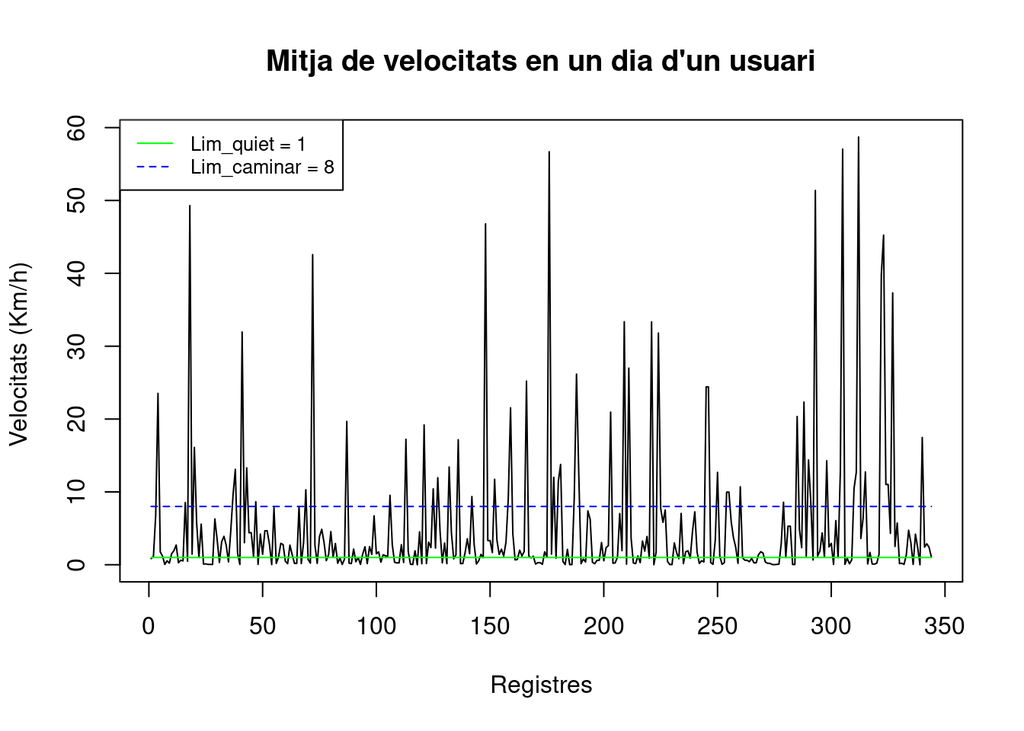

```r
seentime = individu$seentime[1:length(individu$seentime)-1]

lim_quiet = rep(1, times = length(seentime))
lim_caminar = rep(8, times = length(seentime))

plot(proba_velocitats, type = "l", xlab = "Registres", ylab ="Velocitats (Km/h) ", main = "Mitja de velocitats en un dia d'un usuari")
lines(lim_quiet, col="green")
lines(lim_caminar, lty= 2, col = "blue")
legend("topleft", legend=c("Lim_quiet = 1", "Lim_caminar = 8"),
       col=c("green", "blue"), lty=1:2, cex=0.8)
```

#Cocnlusió En veure les velocitats s’observen pics de velocitat, per corregir aquesta errada seria suavitzar aquesta gràfica per obtenir un millor resultat. Filtratge disponible: -Moving Average per k=3,4,5. -Weighted Moving Average descartat, ja que és com l’anterior però incorporant pesos a les mostres. -Simple Exponential Smoothing.

```r
#Filtres
#Moving Average per k=3


k=3

Yt.kMA3 = stats::filter(proba_velocitats, filter=rep(1/k,k))

#Moving Average per k=5
k=5
Yt.kMA5 = stats::filter(proba_velocitats, filter=rep(1/k,k))

Yt.4MAcentered <- stats::filter(proba_velocitats,filter=c(1/8,1/4,1/4,1/4,1/8),sides=2)

#simple exponential smoothing

proba_velocitats_ts = ts(proba_velocitats)

smb = HoltWinters(proba_velocitats_ts, beta = FALSE, gamma = FALSE)
```

Visualització dels suavitzats. Per k=3,4,5 i Simple Exponential Smoothing

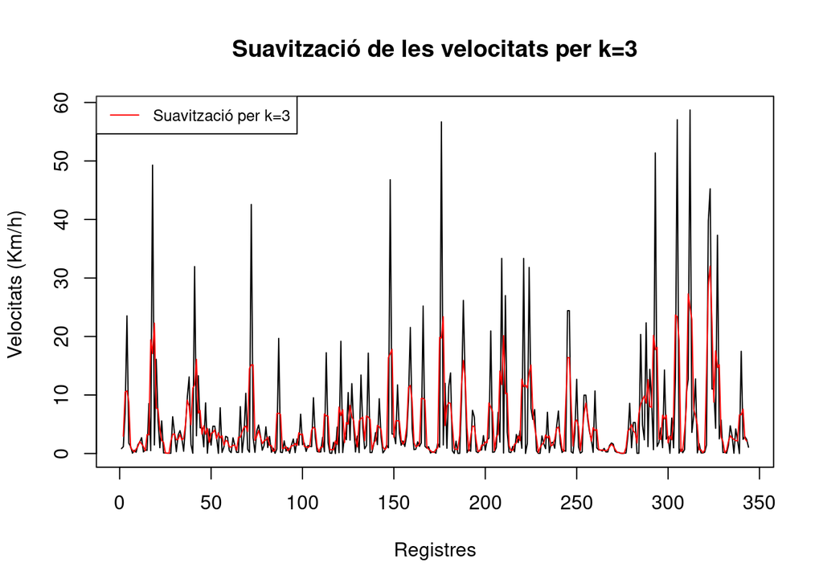

```r
plot( proba_velocitats, type = "l", xlab = "Registres", ylab ="Velocitats (Km/h) ", main = "Suavització de les velocitats per k=3")
lines(Yt.kMA3,col="red")
legend("topleft", legend=c("Suavització per k=3"), col=c("red"), lty=1, cex=0.8)
```

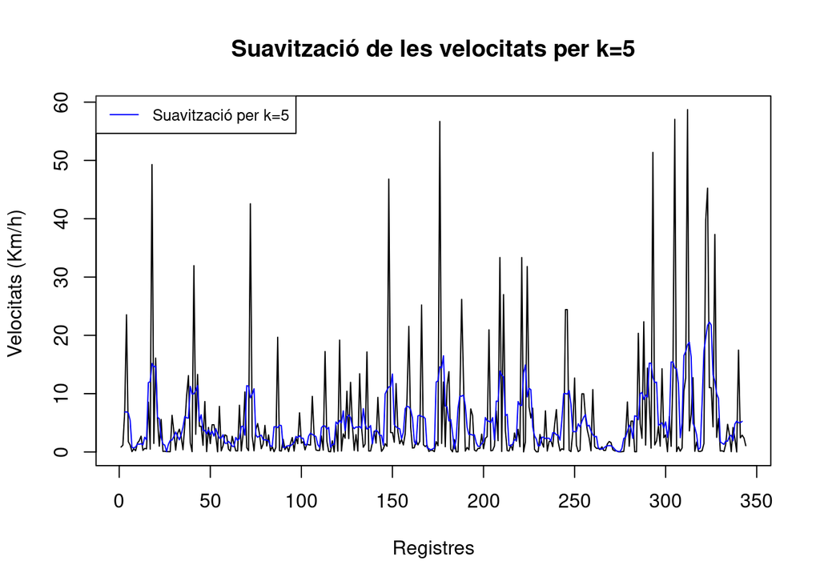

```r
plot( proba_velocitats, type = "l", xlab = "Registres", ylab ="Velocitats (Km/h) ", main = "Suavització de les velocitats per k=5")
lines(Yt.kMA5,col="blue")
legend("topleft", legend=c("Suavització per k=5"), col=c("blue"), lty=1, cex=0.8)
```

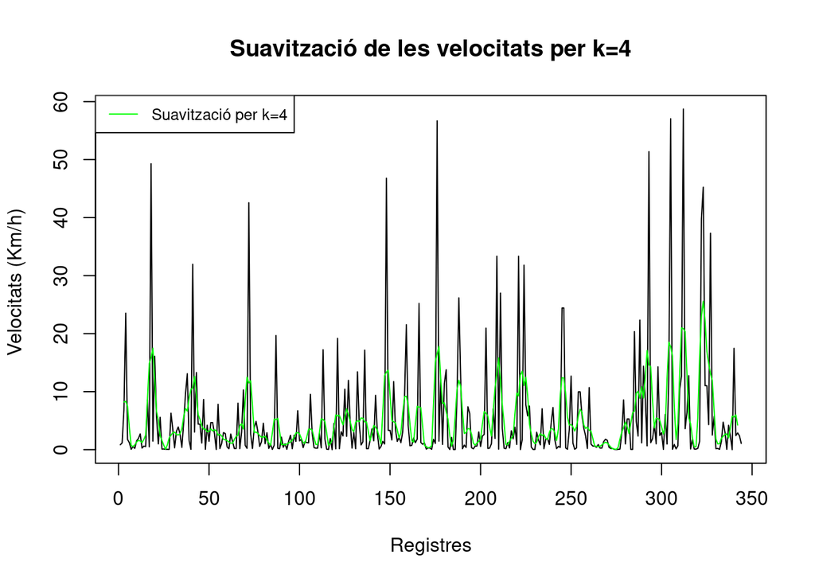

```r
plot( proba_velocitats, type = "l", xlab = "Registres", ylab ="Velocitats (Km/h) ", main = "Suavització de les velocitats per k=4")
lines(Yt.4MAcentered, col="green")
legend("topleft", legend=c("Suavització per k=4"), col=c("green"), lty=1, cex=0.8)
```

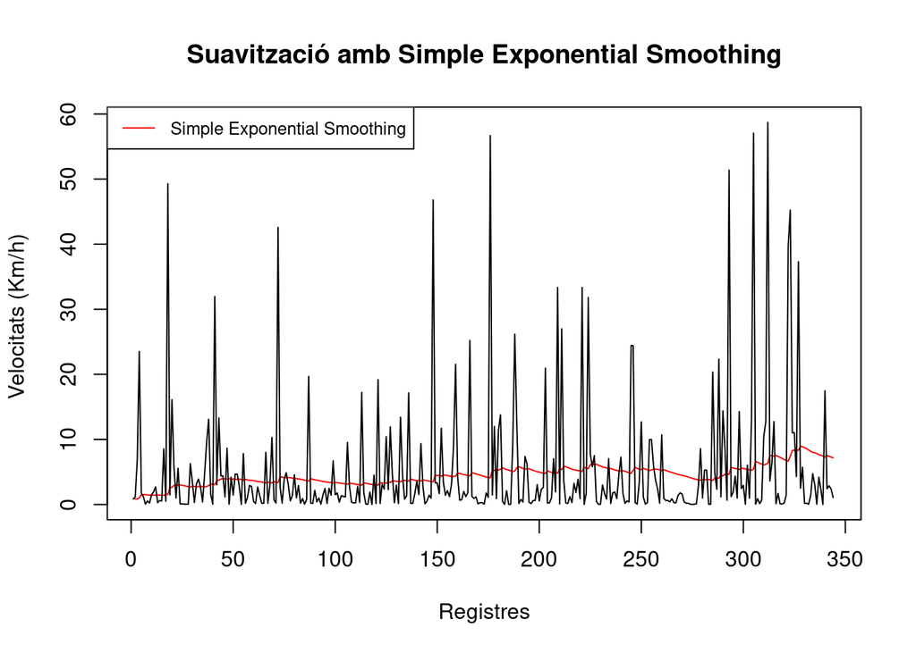

```r
plot(smb, xlab = "Registres", ylab ="Velocitats (Km/h) ", main = "Suavització amb Simple Exponential Smoothing")
legend("topleft", legend=c("Simple Exponential Smoothing"), col=c("red"), lty=1, cex=0.8)
```

```r
#smb = data.frame(as.matrix(smb$fitted))
#smb = smb$level
#smb
```

#Conclusió S’observa que els pics ja són menors. Amb tal cosa que s’han eliminat els punts aberrants i s’han corregit els possibles errors.

El problema és conèixer quin és el millor mètode de suavitzat, ja que no hi ha l’eina que ens indiqui quin és.

Per aquest script s’ha escollit el cas de k=3, però per la versió final aquest pot canviar.

#Agrupacions d’entrades

Períodes de mobilitat que ha tengut Que els que estan per davall del 3 quartil serà un grup

```r
llistat_velocitats = list() #Subgrup de velocitats
contador_llistat = 1

subgrup_velocitats = c()
contador_subgrup = 1

periode_deadline = 358.2 # Periode de deadline


for (i in 1:(length(individu$idreg)-1)) {


  #Obtenir la velocitat en Km/h
  espai = Haversine(individu$lat[i],  individu$lng[i], individu$lat[i+1], individu$lng[i+1])
  temps = (individu$seentime[i+1] - individu$seentime[i])
  Kh = espai*3600/(1000 * temps)
  if(temps <= periode_deadline){

    subgrup_velocitats[contador_subgrup] = Kh
    contador_subgrup =  contador_subgrup + 1

  }else if(!is.null(subgrup_velocitats)){


    llistat_velocitats[[contador_llistat]] = subgrup_velocitats
    contador_llistat = contador_llistat + 1

    subgrup_velocitats = c()
    contador_subgrup = 1
  }




}
head(llistat_velocitats)
```

```
## [[1]]
## [1] 0.8429699
##
## [[2]]
## [1]  6.832313 23.529887
##
## [[3]]
## [1] 1.19034
##
## [[4]]
## [1] 0.5451492
##
## [[5]]
## [1]  1.5153171  1.9304377  2.7068108  0.2693134  0.6093274  0.5345753  8.5419363
## [8]  0.4880600 49.2921282
##
## [[6]]
## [1] 16.106986  5.702667
```

#Conclusió

Aquí podem observar els primers subgrups de l’usuari seleccionat. On hi ha diversos subgrups que tenen una longitud d’1 o 2. En aquests casos no es classificarà el mode de transport. Es posarà el límit a 3 mostres, perquè es pugui classificar. Llavors en el subgrup 5, apareix una velocitat que arriba als 50 Km/h quan la mitja no supera els 10 km/h. Per aquest cas estan les altres mostres per definir el mode de transport. Llavors s’elimina les mostres que tenguin la longitud menor que tres. Finalment l’algoritme quedaria de la següent manera:

```r
llistat_velocitats = list() #Subgrup de velocitats
contador_llistat = 1

subgrup_velocitats = c()
contador_subgrup = 1

periode_deadline = 358.2 # Periode de deadline
mostres_minim = 3


for (i in 1:(length(individu$idreg)-1)) {


  #Obtenir la velocitat en Km/h
  espai = Haversine(individu$lat[i],  individu$lng[i], individu$lat[i+1], individu$lng[i+1])
  temps = (individu$seentime[i+1] - individu$seentime[i])
  Kh = espai*3600/(1000 * temps)
  if(temps <= periode_deadline){

    subgrup_velocitats[contador_subgrup] = Kh
    contador_subgrup =  contador_subgrup + 1

  }else if(!is.null(subgrup_velocitats)){

    if(length(subgrup_velocitats) > mostres_minim){
       llistat_velocitats[[contador_llistat]] = subgrup_velocitats
       contador_llistat = contador_llistat + 1
    }
    subgrup_velocitats = c()
    contador_subgrup = 1
  }




}
head(llistat_velocitats)
```

```
## [[1]]
## [1]  1.5153171  1.9304377  2.7068108  0.2693134  0.6093274  0.5345753  8.5419363
## [8]  0.4880600 49.2921282
##
## [[2]]
## [1] 5.57485811 0.09741275 0.11747819 0.05008108 0.05008108
##
## [[3]]
##  [1]  6.2874009  3.4856978  0.3144376  3.1667967  3.9034612  2.6813099
##  [7]  0.3931942  4.6770274  9.5858926 13.0938075  1.5712893
##
## [[4]]
## [1] 31.94844995  3.03139839 13.29853042  4.39713498  4.39714020  1.14313306
## [7]  8.65425014  0.05545462  4.20956230
##
## [[5]]
## [1] 4.66887048 4.66884535 2.80520783 0.02485114 7.82174317 0.18762093
##
## [[6]]
## [1] 2.9396376 2.7682733 0.4716680 0.1549615 2.6862770 1.3813783 0.1900730
## [8] 0.1900730 8.0088652
```

#Conclusió En tenir més mostres es pot classificar de millor manera al subgrup de velocitats. Indicar que els subgrups es classificaran de manera independent.

## Segona aproximació

Ara per ara solament hi ha una variable que indica el mode de desplaçament que és la velocitat. Però hi ha altres factors que ens poden indicar el seu mode de transport que són: -El nombre diferent d’AP que és connecten -Les zones per allà on es mou l’usuari.

El primer pas serà classificar els diferents APs que està connectat un usuari en subgrup.

```r
llistat_subgrups = list() #Subgrup de velocitats
contador_llistat = 1

subgrup_velocitats = c()
contador_subgrup = 1
k=3 #Filtre



periode_deadline = 358.2 # Periode de deadline
mostres_minim = 5

diferents_ap = NULL


for (i in 1:(length(individu$idreg)-1)) {


  #Obtenir la velocitat en Km/h
  espai = Haversine(individu$lat[i],  individu$lng[i], individu$lat[i+1], individu$lng[i+1])
  temps = (individu$seentime[i+1] - individu$seentime[i])
  Kh = espai*3600/(1000 * temps)
  if(temps <= periode_deadline){

    subgrup_velocitats[contador_subgrup] = Kh
    contador_subgrup =  contador_subgrup + 1

  }else if(!is.null(subgrup_velocitats)){

    if(length(subgrup_velocitats) > mostres_minim){

      #Suavització del subgrup de velocitats
      Yt.kMA3 = stats::filter(subgrup_velocitats, filter=rep(1/k,k))
      Yt.kMA3 <- Yt.kMA3[!is.na(Yt.kMA3)]
      #subgrup_velocitats <- stats::filter(subgrup_velocitats,filter=c(1/8,1/4,1/4,1/4,1/8),sides=2)

      #Contador dels diferents Aps conectats
       ap_conectats = individu[(i-contador_subgrup +2):i,]
       ap_conectats = ap_conectats[!duplicated(ap_conectats$apmac),]
       diferents_ap =   length(ap_conectats$apmac)/(contador_subgrup-1)

       #subgrup_velocitats[contador_subgrup] = diferents_ap
       vector_entrades =c(Yt.kMA3, diferents_ap)

       llistat_subgrups[[contador_llistat]] = vector_entrades
       contador_llistat = contador_llistat + 1
    }
    subgrup_velocitats = c()
    contador_subgrup = 1
  }




}
head(llistat_subgrups)
```

```
## [[1]]
## [1]  2.0508552  1.6355206  1.1951505  0.4710720  3.2286130  3.1881905 19.4407082
## [8]  0.7777778
##
## [[2]]
##  [1] 3.3625121 2.3223107 2.4615652 3.2505226 2.3259884 2.5838438 4.8853714
##  [8] 9.1189091 8.0836631 0.7272727
##
## [[3]]
## [1] 16.0927929  6.9090213  7.3642685  3.3124694  4.7315078  3.2842793  4.3064224
## [8]  0.8888889
##
## [[4]]
## [1] 4.0476412 2.4996348 3.5506007 2.6780717 0.8333333
##
## [[5]]
## [1] 2.0598596 1.1316342 1.1043022 1.4075389 1.4192427 0.5871747 2.7963370
## [8] 0.6666667
##
## [[6]]
## [1] 15.1534549  2.2509932  2.9760033  3.9337246  0.8333333
```

#Conclusió

#Creació de límits per l’elecció dels límits dels diferents APs

```r
length(llistat_subgrups)
```

```
## [1] 17
```

```r
vector_velocitat = c()
vector_daps = c()
contador_daps = 1

contador_quiet = 0
contador_caminar = 0
#contador_bicicleta = 0
contador_altres = 0



for( i in 1:length(llistat_subgrups)){

  for(l in 1:(length(llistat_subgrups[[i]])-1)){
    if(llistat_subgrups[[i]][l] < 2){contador_quiet = contador_quiet + 1}
    if(llistat_subgrups[[i]][l] > 3 && llistat_subgrups[[i]][l] < 7){contador_caminar = contador_caminar + 1 }
    #if(llistat_subgrups[[i]][l] > 12 && llistat_subgrups[[i]][l] < 16){contador_bicicleta = contador_bicicleta + 1}
    if(llistat_subgrups[[i]][l] > 30 && llistat_subgrups[[i]][l] < 50){contador_altres = contador_altres + 1}

  }
  Probabilitat_quiet = contador_quiet/(length(llistat_subgrups[[i]])-1)
  Probabilitat_caminar = contador_caminar/(length(llistat_subgrups[[i]])-1)
  #Probabilitat_bicicleta = contador_bicicleta/(length(llistat_subgrups[[i]])-1)
  Probabilitat_altres = contador_altres/(length(llistat_subgrups[[i]])-1)

  if(Probabilitat_quiet > 0.5){
    vector_velocitat[i] = 0
  }else if(Probabilitat_caminar > 0.5){
    vector_velocitat[i] = 1
  #}else if(Probabilitat_bicicleta > 0.5){
   # vector_velocitat[i] = 2
  }else if(Probabilitat_altres > 0.5){
    vector_velocitat[i] = 2
  }else{
    vector_velocitat[i] = NA
  }

  #Una proba per veure si funciona
   vector_daps[contador_daps] = llistat_subgrups[[i]][length(llistat_subgrups[[i]])]
     contador_daps = contador_daps +1

 # if(!is.na(vector_velocitat[i])){
     #vector_daps[contador_daps] = llistat_subgrups[[i]][length(llistat_subgrups[[i]])]
     #contador_daps = contador_daps +1
  #}


  contador_quiet = 0
  contador_caminar = 0
  #contador_bicicleta = 0
  contador_altres = 0
}
```

```r
vector_velocitat
```

```
##  [1] NA NA  1 NA  0 NA  0  1  1 NA NA NA NA  1  1 NA NA
```

Com es pot veure hi ha uns valors que directament són NA. Això és a causa que no superen el mínim. Però amb els valors obtinguts. Per aquesta necessitat requereix de la utilització dels diferents APs connectats en el subgrup.

Per aquesta raó s’utilitzarà una multinomial-logistic-regression

## Multinomial logistic regression

En aquesta secció es realitzarà una cerca d’una multinomial logistic regression, ja que a partir d’un valor que és la de diferents APs connectats en un subgrup.

Per realitzar una petita prova es recollirà els subgrups de l’individu dit. On a partir d’una variable (les velocitats) coneixerem.

```r
#vector_velocitat = vector_velocitat[!is.na(vector_velocitat)]
vector_daps
```

```
##  [1] 0.7777778 0.7272727 0.8888889 0.8333333 0.6666667 0.8333333 0.8333333
##  [8] 0.8750000 0.6666667 0.6363636 0.4444444 0.7500000 0.8333333 0.4285714
## [15] 0.5454545 0.4444444 0.6666667
```

```r
vector_velocitat
```

```
##  [1] NA NA  1 NA  0 NA  0  1  1 NA NA NA NA  1  1 NA NA
```

```r
proba = data.frame(vector_velocitat, vector_daps)
head(proba)
```

```
##   vector_velocitat vector_daps
## 1               NA   0.7777778
## 2               NA   0.7272727
## 3                1   0.8888889
## 4               NA   0.8333333
## 5                0   0.6666667
## 6               NA   0.8333333
```

```r
summary(proba)
```

```
##  vector_velocitat  vector_daps
##  Min.   :0.0000   Min.   :0.4286
##  1st Qu.:0.5000   1st Qu.:0.6364
##  Median :1.0000   Median :0.7273
##  Mean   :0.7143   Mean   :0.6972
##  3rd Qu.:1.0000   3rd Qu.:0.8333
##  Max.   :1.0000   Max.   :0.8889
##  NA's   :10
```

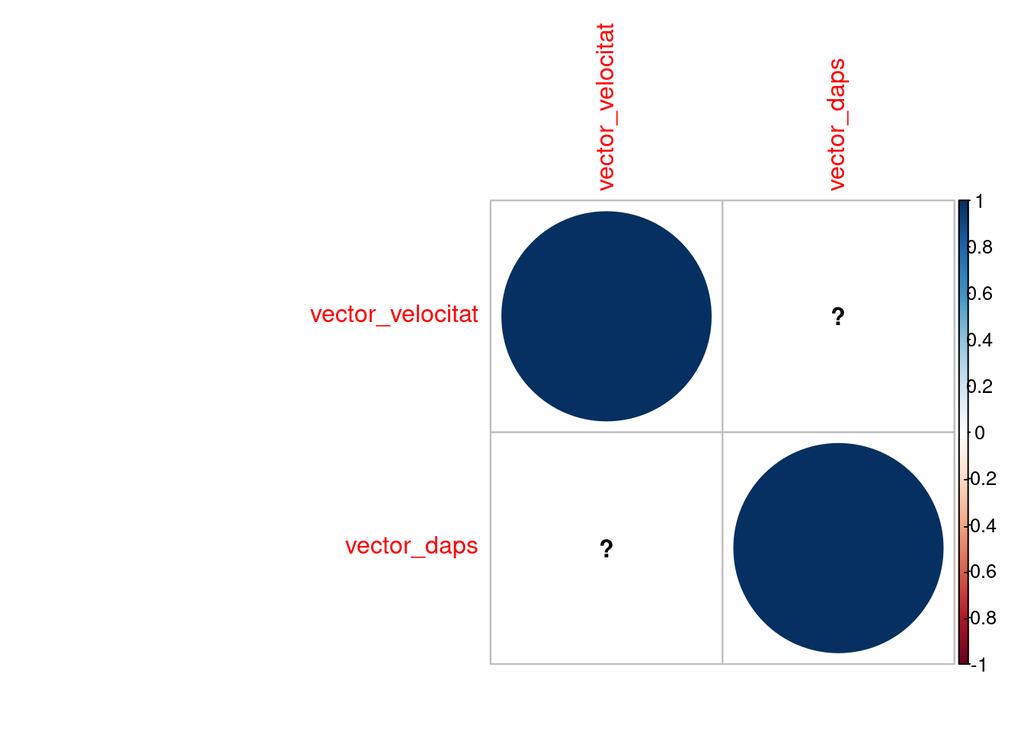

```r
#library(corrplot)
correlations <- cor(proba)
corrplot(correlations, method="circle")
```

```r
# Logistics Regression
glm.fit <- glm(vector_velocitat ~ vector_daps, data = proba, family = binomial)
```

```r
glm.probs <- predict(glm.fit,type = "response")
glm.probs[1:5]
```

```
##         3         5         7         8         9
## 0.6068361 0.7419490 0.6432630 0.6160730 0.7419490
```

```r
glm.pred <- ifelse(glm.probs > 0.5, "caminar", "quiet")
glm.pred
```

```
##         3         5         7         8         9        14        15
## "caminar" "caminar" "caminar" "caminar" "caminar" "caminar" "caminar"
```

```r
modelo = lm(vector_velocitat~ vector_daps, data = proba)
modelo
```

```
##
## Call:
## lm(formula = vector_velocitat ~ vector_daps, data = proba)
##
## Coefficients:
## (Intercept)  vector_daps
##      1.0904      -0.5368
```

```r
#otros = c(0.3 , 0.5, 0.6, 0.8, 0.9)
daps = data.frame(vector_daps)
vector_daps
```

```
##  [1] 0.7777778 0.7272727 0.8888889 0.8333333 0.6666667 0.8333333 0.8333333
##  [8] 0.8750000 0.6666667 0.6363636 0.4444444 0.7500000 0.8333333 0.4285714
## [15] 0.5454545 0.4444444 0.6666667
```

```r
aaaa = predict(modelo, newdata = daps, interval = "prediction")
aaaa
```

```
##          fit        lwr      upr
## 1  0.6728878 -0.7887822 2.134558
## 2  0.6999977 -0.7438418 2.143837
## 3  0.6132460 -0.9449622 2.171454
## 4  0.6430669 -0.8575090 2.143643
## 5  0.7325296 -0.7128385 2.177898
## 6  0.6430669 -0.8575090 2.143643
## 7  0.6430669 -0.8575090 2.143643
## 8  0.6207012 -0.9214465 2.162849
## 9  0.7325296 -0.7128385 2.177898
## 10 0.7487955 -0.7067236 2.204315
## 11 0.8518131 -0.7994703 2.503097
## 12 0.6877982 -0.7619408 2.137537
## 13 0.6430669 -0.8575090 2.143643
## 14 0.8603334 -0.8158684 2.536535
## 15 0.7975933 -0.7241932 2.319380
## 16 0.8518131 -0.7994703 2.503097
## 17 0.7325296 -0.7128385 2.177898
```

```r
glm.pred <- ifelse(aaaa[,1] > 0.5, "caminar", "quiet")
glm.pred
```

```
##         1         2         3         4         5         6         7         8
## "caminar" "caminar" "caminar" "caminar" "caminar" "caminar" "caminar" "caminar"
##         9        10        11        12        13        14        15        16
## "caminar" "caminar" "caminar" "caminar" "caminar" "caminar" "caminar" "caminar"
##        17
## "caminar"
```

# Conclusió

## Arees per on viatgen els individus

La segona eina és conéixer per quines zones viatgen els individus. No és el mateix viatjar per la plaça d’espanya, que viatjar per el passeig maritim. També que el nombre de zones wifi que es visiten. Per aquesta raó carga la base de dades dels access points.

```r
aps_informacio = read.csv("~/Escritorio/TFM/distribucioaps.csv", header = TRUE, sep = ',')
str(aps_informacio)
```

```
## 'data.frame':    114 obs. of  7 variables:
##  $ mac          : Factor w/ 114 levels "00:18:0a:03:04:bc",..: 22 23 11 95 110 106 77 89 78 74 ...
##  $ name         : Factor w/ 114 levels "Anima Beach - Gat. Anima",..: 114 113 68 69 112 111 6 5 7 71 ...
##  $ lat          : num  39.6 39.6 39.6 39.6 39.6 ...
##  $ lng          : num  2.64 2.64 2.64 2.64 2.64 ...
##  $ zona         : Factor w/ 12 levels "SmartWiFiPalma Zona 0",..: 1 1 1 1 1 1 2 2 2 2 ...
##  $ zona_name    : Factor w/ 12 levels "Av. Jaume III",..: 4 4 4 4 4 4 6 6 6 6 ...
##  $ zona_abreviat: num  1 1 1 1 1 1 2 2 2 2 ...
```

```r
head(aps_informacio)
```

```
##                 mac                                    name      lat      lng
## 1 00:18:0a:04:78:72             Mar de Nudos - Gat. Terraza 39.56675 2.644041
## 2 00:18:0a:04:a1:ca        Mar de Nudos - Gat. Mar de Nudos 39.56665 2.643939
## 3 00:18:0a:03:12:1a                Gat. Moll Vell - Amarres 39.56608 2.643238
## 4 88:15:44:2c:34:60 Gat. Moll Vell - Restaurante Port Blanc 39.56623 2.643587
## 5 88:15:44:59:3e:d0          Gat. Varadero Parada Autobuses 39.56510 2.643442
## 6 88:15:44:59:07:80                           Gat. Varadero 39.56377 2.641878
##                    zona zona_name zona_abreviat
## 1 SmartWiFiPalma Zona 0 Moll Vell             1
## 2 SmartWiFiPalma Zona 0 Moll Vell             1
## 3 SmartWiFiPalma Zona 0 Moll Vell             1
## 4 SmartWiFiPalma Zona 0 Moll Vell             1
## 5 SmartWiFiPalma Zona 0 Moll Vell             1
## 6 SmartWiFiPalma Zona 0 Moll Vell             1
```

S’han d’afegir els factors que té l’altre. Això no faltaria si la base de dades dels aps estiguessin actualitzades.

```r
aps_informacio[,2] = factor(aps_informacio[,2], levels = levels(individu$apmac))
```

```r
llistat_subgrups = list() #Subgrup de velocitats
contador_llistat = 1

subgrup_velocitats = c()
contador_subgrup = 1

periode_deadline = 358.2 # Periode de deadline
mostres_minim = 3

diferents_ap = NULL

temps_Inicial= c()


for (i in 1:(length(individu$idreg)-1)) {


  #Obtenir la velocitat en Km/h
  espai = Haversine(individu$lat[i],  individu$lng[i], individu$lat[i+1], individu$lng[i+1])
  temps = (individu$seentime[i+1] - individu$seentime[i])
  Kh = espai*3600/(1000 * temps)
  if(temps <= periode_deadline){

    subgrup_velocitats[contador_subgrup] = Kh
    contador_subgrup =  contador_subgrup + 1

  }else if(!is.null(subgrup_velocitats)){

    if(length(subgrup_velocitats) > mostres_minim){


       ap_conectats = individu[(i-contador_subgrup +2):i,]
       ap_conectats = ap_conectats[!duplicated(ap_conectats$apmac),]

       #Suavització del subgrup de velocitats

        #Suavització del subgrup de velocitats per solament k=3
        #k=3
        #Yt.kMA3 = stats::filter(subgrup_velocitats, filter=rep(1/k,k))
        #Yt.kMA3 <- Yt.kMA3[!is.na(Yt.kMA3)]

       n=round(length(subgrup_velocitats)*0.2)
       k=2*n+1      #Ha de ser impar
       Yt.kMA = stats::filter(subgrup_velocitats, filter=rep(1/k,k))
       Yt.kMA <- Yt.kMA[!is.na(Yt.kMA)]


       #Per tenir els mateixos nivels de factors
       ap_conectats$apmac = factor(ap_conectats$apmac, levels = levels(aps_informacio$mac))





       subgrup_velocitats_ts =  ts(subgrup_velocitats)

       smb = HoltWinters(subgrup_velocitats_ts, beta = FALSE, gamma = FALSE)

       smb = data.frame(as.matrix(smb$fitted))
       smb = smb$level





      #subgrup_velocitats <- stats::filter(subgrup_velocitats,filter=c(1/8,1/4,1/4,1/4,1/8),sides=2)


       #Arees diferents que han visitat els dispositius
       zones_diferents = aps_informacio[aps_informacio$mac == ap_conectats$apmac ,]
       zones_diferents= zones_diferents[!duplicated(zones_diferents$zona),]

       zones_diferents = zones_diferents[!is.na(zones_diferents$zona)]

       zones_visitades = length(zones_diferents$zona)

       # Com a mínim tendria que sortir una zona que han visitat, com que falten dades, es deixarà amb 1
       if(zones_visitades == 0){zones_visitades = 1}



       temps_Inicial[contador_llistat] = individu$seentime[(i-contador_subgrup +2)]

       diferents_ap =   length(ap_conectats$apmac)/(contador_subgrup-1)

       #subgrup_velocitats[contador_subgrup] = diferents_ap

       #subgrup_velocitats[contador_subgrup + 1] = zones_visitades


       #vector_entrades =c(Yt.kMA, diferents_ap, zones_visitades)
       vector_entrades =c(smb, diferents_ap, zones_visitades)

       llistat_subgrups[[contador_llistat]] = vector_entrades
       contador_llistat = contador_llistat + 1
    }
    subgrup_velocitats = c()
    contador_subgrup = 1
  }




}
head(llistat_subgrups)
```

```
## [[1]]
##  [1] 1.5153171 1.6795797 2.0860537 1.3671720 1.0672939 0.8564979 3.8976154
##  [8] 2.5484590 0.7777778 1.0000000
##
## [[2]]
## [1] 5.57485811 0.11724821 0.11747736 0.05032514 0.60000000 1.00000000
##
## [[3]]
##  [1] 6.2874009 6.0862949 5.6719913 5.4921686 5.3781313 5.1845536 4.8406302
##  [8] 4.8288868 5.1703443 5.7390900 0.7272727 1.0000000
##
## [[4]]
##  [1] 31.9484500 11.9483084 12.8821737  7.0135956  5.2039547  2.3953348
##  [7]  6.7242406  2.1118525  0.8888889  1.0000000
##
## [[5]]
## [1] 4.6688705 4.6688698 4.6181529 4.4931526 4.5837355 0.8333333 1.0000000
##
## [[6]]
##  [1] 2.9396376 2.9391581 2.9322543 2.9244836 2.9238171 2.9195015 2.9118648
##  [8] 2.9042495 0.6666667 1.0000000
```

```r
length(llistat_subgrups)
```

```
## [1] 29
```

```r
vector_velocitat = c()
vector_daps = c()
vector_zones = c()
contador_daps = 1

contador_quiet = 0
contador_caminar = 0
#contador_bicicleta = 0
contador_altres = 0

Probabilitat_quiet = c()
Probabilitat_caminar = c()
#Probabilitat_bicicleta = c()
Probabilitat_altres = c()


for( i in 1:length(llistat_subgrups)){

    for(l in 1:(length(llistat_subgrups[[i]])-2)){
    if(llistat_subgrups[[i]][l] < 2){contador_quiet = contador_quiet + 1}
    if(llistat_subgrups[[i]][l] > 3 && llistat_subgrups[[i]][l] < 8){contador_caminar = contador_caminar + 1 }
    #if(llistat_subgrups[[i]][l] > 12 && llistat_subgrups[[i]][l] < 16){contador_bicicleta = contador_bicicleta + 1}
    if(llistat_subgrups[[i]][l] > 12 && llistat_subgrups[[i]][l] < 60){contador_altres = contador_altres + 1}

  }
  Probabilitat_quiet[i] = contador_quiet/(length(llistat_subgrups[[i]])-2)
  Probabilitat_caminar[i] = contador_caminar/(length(llistat_subgrups[[i]])-2)
  #Probabilitat_bicicleta[i] = contador_bicicleta/(length(llistat_subgrups[[i]])-2)
  Probabilitat_altres[i] = contador_altres/(length(llistat_subgrups[[i]])-2)

  if(Probabilitat_quiet[i] > 0.5){
    vector_velocitat[i] = 0
  }else if(Probabilitat_caminar[i] > 0.5){
    vector_velocitat[i] = 1
  #}else if(Probabilitat_bicicleta[i] > 0.5){
  #  vector_velocitat[i] = 2
  }else if(Probabilitat_altres[i] > 0.5){
    vector_velocitat[i] = 2
  } else{
    vector_velocitat[i] = NA
  }

  #Una proba per veure si funciona
   vector_daps[contador_daps] = llistat_subgrups[[i]][length(llistat_subgrups[[i]])-1]


   vector_zones[contador_daps] = llistat_subgrups[[i]][length(llistat_subgrups[[i]])]
     contador_daps = contador_daps +1



 # if(!is.na(vector_velocitat[i])){
     #vector_daps[contador_daps] = llistat_subgrups[[i]][length(llistat_subgrups[[i]])]
     #contador_daps = contador_daps +1
  #}


  contador_quiet = 0
  contador_caminar = 0
  contador_bicicleta = 0
  contador_altres = 0
}
#length(vector_velocitat)
```

A diferencia de la versió 1 tenim un altre variable que ens permetrá diferenciar més bé les velocitats.

També s’afegiran variables de les probabilitats d’estar quiet, caminant i altres.

```r
proba = data.frame(vector_velocitat, vector_daps, vector_zones,Probabilitat_quiet, Probabilitat_caminar, Probabilitat_altres )
head(proba)
```

```
##   vector_velocitat vector_daps vector_zones Probabilitat_quiet
## 1                0   0.7777778            1              0.625
## 2                0   0.6000000            1              0.750
## 3                1   0.7272727            1              0.000
## 4               NA   0.8888889            1              0.000
## 5                1   0.8333333            1              0.000
## 6               NA   0.6666667            1              0.000
##   Probabilitat_caminar Probabilitat_altres
## 1                0.125                0.00
## 2                0.250                0.00
## 3                1.000                0.00
## 4                0.375                0.25
## 5                1.000                0.00
## 6                0.000                0.00
```

```r
summary(proba)
```

```
##  vector_velocitat  vector_daps      vector_zones   Probabilitat_quiet
##  Min.   :0.0000   Min.   :0.4286   Min.   :1.000   Min.   :0.0000
##  1st Qu.:0.0000   1st Qu.:0.6000   1st Qu.:1.000   1st Qu.:0.0000
##  Median :1.0000   Median :0.7500   Median :1.000   Median :0.3333
##  Mean   :0.6875   Mean   :0.7173   Mean   :1.138   Mean   :0.3291
##  3rd Qu.:1.0000   3rd Qu.:0.8333   3rd Qu.:1.000   3rd Qu.:0.5000
##  Max.   :2.0000   Max.   :1.0000   Max.   :2.000   Max.   :1.0000
##  NA's   :13
##  Probabilitat_caminar Probabilitat_altres
##  Min.   :0.0000       Min.   :0.0000
##  1st Qu.:0.1250       1st Qu.:0.0000
##  Median :0.2500       Median :0.0000
##  Mean   :0.3266       Mean   :0.1555
##  3rd Qu.:0.4286       3rd Qu.:0.2500
##  Max.   :1.0000       Max.   :1.0000
##
```

```r
length(llistat_subgrups)
```

```
## [1] 29
```

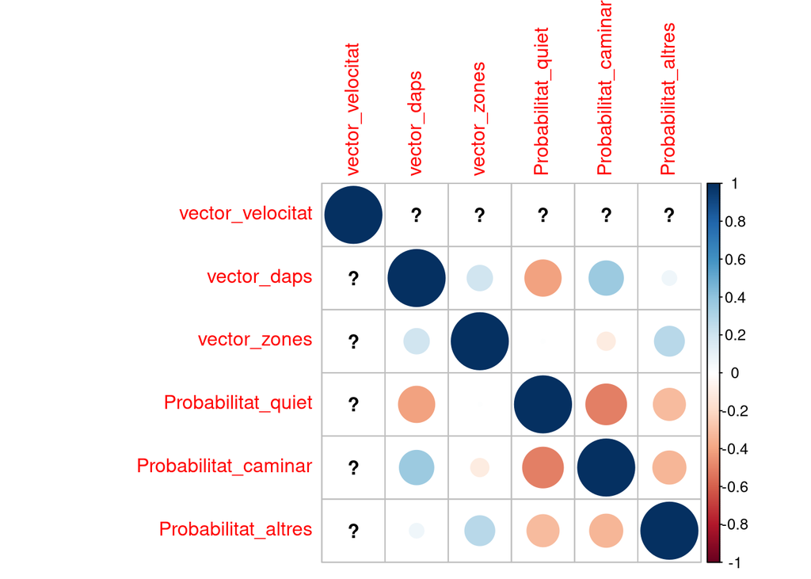

```r
library(corrplot)
correlations <- cor(proba)
corrplot(correlations, method="circle")
```

```r
# Logistics Regression
#glm.fit <- lm(vector_velocitat ~ vector_daps + vector_zones, data = proba)
#vector_velocitat[3] = 2
vector_velocitat
```

```
##  [1]  0  0  1 NA  1 NA NA  0  0  1 NA NA  1 NA NA  0 NA  0 NA NA  1 NA  2  1 NA
## [26] NA  2  0  1
```

```r
modelo2 <- lm(vector_velocitat ~ vector_daps + vector_zones + Probabilitat_quiet + Probabilitat_caminar + Probabilitat_altres, data = proba)
```

```r
predicio = data.frame(vector_daps,vector_zones,Probabilitat_quiet, Probabilitat_caminar, Probabilitat_altres )


prediccion = predict(modelo2, newdata = predicio, interval = "prediction")
```

```r
#glm.pred <- ifelse(aaaa[,1] > 0.5, "caminar", "quiet")
prediction = c()
for (i in 1:length(prediccion[,1])) {
  if(prediccion[i,1] < 0.5 ){prediction[i] = 0}
  if(prediccion[i,1] > 0.5 && prediccion[i,1] < 1.5){prediction[i] =1}
  if(prediccion[i,1] > 1.5){prediction[i] = 2}
}
length(prediction)
```

```
## [1] 29
```

```r
length(temps_Inicial)
```

```
## [1] 29
```

```r
temps_UTC = anytime(temps_Inicial)
temps_UTC
```

```
##  [1] "2019-07-24 02:42:38 CEST" "2019-07-24 03:26:19 CEST"
##  [3] "2019-07-24 03:48:46 CEST" "2019-07-24 04:21:44 CEST"
##  [5] "2019-07-24 04:42:27 CEST" "2019-07-24 05:12:36 CEST"
##  [7] "2019-07-24 05:52:33 CEST" "2019-07-24 09:24:27 CEST"
##  [9] "2019-07-24 10:41:35 CEST" "2019-07-24 11:14:07 CEST"
## [11] "2019-07-24 11:46:15 CEST" "2019-07-24 12:46:48 CEST"
## [13] "2019-07-24 14:31:37 CEST" "2019-07-24 14:56:58 CEST"
## [15] "2019-07-24 15:26:20 CEST" "2019-07-24 16:09:37 CEST"
## [17] "2019-07-24 17:08:08 CEST" "2019-07-24 17:25:58 CEST"
## [19] "2019-07-24 18:05:43 CEST" "2019-07-24 19:40:23 CEST"
## [21] "2019-07-24 20:06:52 CEST" "2019-07-24 22:00:17 CEST"
## [23] "2019-07-24 22:39:28 CEST" "2019-07-24 22:55:09 CEST"
## [25] "2019-07-24 23:18:22 CEST" "2019-07-24 23:49:59 CEST"
## [27] "2019-07-25 00:33:24 CEST" "2019-07-25 00:48:20 CEST"
## [29] "2019-07-25 01:12:43 CEST"
```

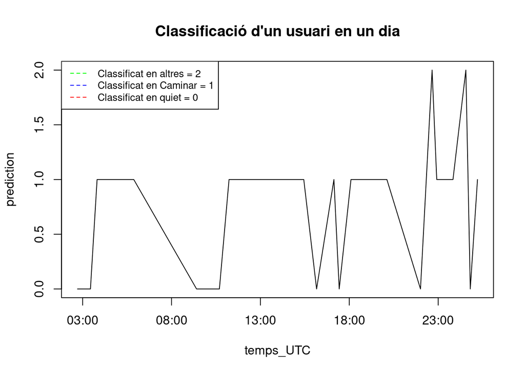

```r
lim_quiet = rep(0, times = length(prediction))
lim_caminar = rep(1, times = length(prediction))
lim_altres = rep(2, times = length(prediction))
plot(y=prediction, x=temps_UTC, type = "l", main= "Classificació d'un usuari en un dia")
lines(lim_quiet, lty=2, col="red")
lines(lim_caminar, lty=2, col="blue")
lines(lim_altres, lty=2, col="green")
legend("topleft", legend=c("Classificat en altres = 2","Classificat en Caminar = 1", "Classificat en quiet = 0"), col=c("green","blue","red"), lty=2, cex=0.8)
```

#Conclusió algoritme

Es pot observar en el resultat l’evolució dels temps segons l’usuari. On sol estar en moviment la gran majoria del temps, en aquesta gràfica no consta la finalització dels subgrups. Però s’observa que un usuari no sempre utilitza el mateix tipus de transport. Pel tema si aquest fet correspon a la realitat, és difícil conèixer quina accuracy té l’algoritme, pot estar el cas que tengui una millor aproximació un altre algoritme o un altre tipus de suavització.